# Patient-Generated Health Data as a Predictor of Adverse Outcomes in Veterans

Study 1 — Pre-Event PGHD Surveillance Cohort

Nick Cardamone

May 22, 2026

Table S1. Missingness rates before imputation. Only features with >0% missing shown.

| Feature | % Missing |
| --- | --- |
| albumin_value_mean | 90.5 |
| albumin_value_last | 90.5 |
| leuk_value_mean | 90.4 |
| leuk_value_last | 90.4 |
| bun_value_mean | 86.4 |
| bun_value_last | 86.4 |
| bmi_slope | 35.0 |
| bmi_fitted_mean | 35.0 |
| bmi_fitted_last | 35.0 |
| map_slope | 32.7 |
| map_fitted_mean | 32.7 |
| map_fitted_last | 32.7 |
| recent_pulse | 29.8 |
| current_smoker | 21.1 |
| never_smoker | 21.1 |
| PriorityGroup | 12.2 |
| Race | 8.9 |
| Ethnicity | 4.9 |
| mst_status | 3.9 |
| MaritalStatus | 2.0 |
| GISURH | 0.4 |
| Age | 0.2 |
| Gender | 0.2 |
| py2_acute_renal_failure | 0.2 |
| py2_artificial_openings | 0.2 |
| py2_chronic_pancreatitis | 0.2 |
| py2_chronic_ulcer_skin | 0.2 |
| py2_congestive_heart_failure | 0.2 |
| py2_drug_alcohol_dependence | 0.2 |
| py2_drug_alcohol_psychosis | 0.2 |
| py2_lung_severe_cancers | 0.2 |
| py2_metastatic_cancer | 0.2 |
| py2_pregnancy | 0.2 |
| py2_heart_arrhythmias | 0.2 |
| py2_financial_sdoh | 0.2 |
| py2_housing_instability | 0.2 |
| py2_nonspecific_psychosocial | 0.2 |
| py2_dialysis_access | 0.2 |
| py2_dialysis_status | 0.2 |
| py2_mwi_score | 0.2 |
| py2_inpat_any | 0.2 |
| py2_inpat_med_surg | 0.2 |
| py2_inpat_mental_health | 0.2 |
| py2_inpat_nursing_home | 0.2 |
| py2_inpat_other | 0.2 |
| py2_IVC | 0.2 |
| py2_IVC_n | 0.2 |
| py2_IVC_los | 0.2 |
| cci_score | 0.2 |
| py_ed | 0.2 |
| py_urgent | 0.2 |
| py_appt_no_show | 0.2 |
| k_steps_7d_avg_pctdiff | 0.1 |

# Methods

## Data

This study uses Patient-Generated Health Data (PGHD) from the VA Wearable Technology Program, in which Veterans voluntarily enrolled and shared wearable device data (Fitbit, Garmin, or Apple Health). Data were obtained from **January 01, 2022** through **April 14, 2026**. Daily step counts from Fitbit and Garmin devices were prioritized (using the higher value when both were present); Apple Health data served as an alternative when Fitbit/Garmin data were unavailable. A total of 8,858,283 patient-days had usable step data; Fitbit/Garmin data were available for 13.3% and Apple Health for the remainder. Daily step counts of zero were treated as missing, and outliers were removed using the 1.5×IQR method applied to raw device columns. Where step data were missing but exercise duration (minutes) was recorded, steps were imputed from a linear regression model fit on matched days (`steps ~ exercise_minutes`).

## Cohort Derivation (Figure 1)

The analytic cohort was drawn from Veterans who had enrolled in the VA Wearable Technology Program with PGHD data available from **January 01, 2022** through **April 14, 2026**. The single eligibility criterion was a first PGHD upload on or before **March 16, 2025** (N = 13,184), derived as the latest first-upload date for which 52 weeks of potential observation remain before the data extract end date. This ensures a uniform 52-week observation window for every included patient. We then applied a weekly data quality filter requiring at least four upload days per 7-day window (`miss_days ≤ 3`), and retained only patients who had at least one qualifying week in the baseline period (calendar weeks 1–6; days 1–42 after each patient’s actual first upload date) and at least one qualifying observation week (week 7 onward). Calendar weeks are indexed relative to each patient’s actual first upload date (week 1 = days 1–7, week 2 = days 8–14, etc.). Patients whose composite event (ED visit, inpatient admission, or death) occurred within the first 42 days after first upload (calendar weeks 1–6) were additionally excluded, as no event-free anchor period exists for them. Observation windows were then censored at the date of a first composite event or at 52 weeks from first upload, whichever came first. The final analytic cohort included **10,112 Veterans** contributing **322,774 person-weeks** of observation (weeks 7+).

## Step Feature Construction

At each observation week, a suite of step-derived features was computed from the 7-day, 14-day, and 21-day rolling windows anchored to the calendar week end-date. The primary current-activity features include the 7-day rolling average daily step count (`k_steps_7d_avg`, thousands), the rolling standard deviation (`k_steps_7d_sd`), the number of missing days in the window (`k_steps_7d_miss_days`), and the count of days with <1,000 steps (`low_activity_days_7d`). Two change metrics capture temporal trends: percent change from the average of the prior three 7-day windows (`k_steps_7d_avg_pctdiff`, winsorized at ±500%) and percent change from the 6-week baseline average (`k_steps_7d_pct_from_baseline`). Analogous 14-day and 21-day rolling averages and standard deviations provide longer-horizon smoothed signals. Two baseline summary features — mean steps and mean missing days across weeks 1–6 — anchor the within-person normalization.

Taken together, the step features implement a Mundlak-style decomposition for the primary activity signal. `baseline_k_steps_avg` — the patient’s mean daily step count across the six baseline weeks, fixed at enrollment — serves as the between-person anchor, capturing stable individual-level activity capacity. `k_steps_7d_pct_from_baseline` and `k_steps_7d_avg_pctdiff` represent within-person deviations from that anchor, capturing departures from the patient’s own history over medium and short horizons respectively. Because the baseline is computed exclusively from pre-observation data (weeks 1–6), all deviation features are computable at any future prediction point without requiring knowledge of future step counts — a prerequisite for prospective deployment.

## Outcome Definition

The primary outcome was a composite of ED visit, inpatient admission, or death occurring within the prediction horizon (14 or 30 days) following a given observation week’s end date. The outcome was labeled positive (Y = 1) if any component occurred within 1 to *h* days (`days_to_event ∈ [1, h]`), and negative (Y = 0) otherwise. Observations within 30 days of the end of follow-up without a recorded event were excluded if the outcome window was not fully observed.

## Statistical Analysis

We fit three feature sets: (1) step-derived features only (baseline + dynamic, *n* = 14 features); (2) static clinical features only (demographics, comorbidity flags, prior healthcare utilization, vitals, labs, and social history); and (3) the combined set. For each feature set and each prediction horizon (14-day and 30-day), we trained two algorithm types: penalized logistic regression (with elastic-net preprocessing) and gradient-boosted trees (XGBoost). Patients were randomly assigned to training (70%) and testing (30%) sets; all observation-weeks for a given patient remained in the same partition. To address class imbalance, logistic regression models were trained on patient-aware 3:1 undersampled data with case weights applied proportionally; XGBoost models were trained on the full (non-undersampled) training data with `scale_pos_weight` set to the true negative-to-positive ratio, avoiding the probability compression that results from training and scoring on different class distributions. Predicted probabilities were Platt-scaled (logistic calibration) on the test set; Platt-scaled probabilities were used to compute AUC-ROC and PR-AUC. Calibration slope was computed on the raw (pre-calibration) model output to provide an unbiased measure of model calibration. Brier score was computed but is not reported as a primary metric, as the low event rate (<3% per week) renders it statistically equivalent to the null (intercept-only) model.

## Figure 1. Cohort Derivation

Figure 1. Cohort derivation flow table for Study 1. Person-weeks shown for observation period (weeks 7+) at steps 4–5; earlier rows show total qualifying weekly rows before baseline/observation split.

Step

Criterion

Veterans

Person-weeks

0. All enrolled PGHD patients

All Veterans with qualifying PGHD data from January 01, 2022 through April 14, 2026

23,014

1,480,400

1. Uniform follow-up window

First PGHD upload on or before March 16, 2025 (52 weeks of potential follow-up for every patient)

13,184

1,200,355

2. Weekly data quality

≥4 days with step data in a given 7-day window (miss_days ≤ 3)

13,110

1,066,994

3. Baseline and observation weeks present

At least one qualifying week in baseline (calendar weeks 1–6, days 1–42 after first upload) and at least one qualifying observation week (week 7+)

10,887

938,759

4. Event-free baseline required

Exclude patients whose composite event occurred within the first 42 days after first upload (calendar weeks 1–6)

10,376

902,094

5. Censor at first event or follow-up window end

Remove person-weeks after first composite event or 52-week window end. Of the 264 patients excluded: (a) 123 had their composite event before their first qualifying observation week end-date (event occurred during or before the week-7 transition period, leaving no complete prediction window); (b) 141 enrolled early but had insufficient PGHD data quality during their 52-week observation window - their first qualifying observation week only appeared after the window closed, reflecting prolonged gaps or low upload engagement rather than a clinical event.

10,112

322,774

## Cohort Derivation Diagnostics

The sections below inspect each CONSORT exclusion step to verify that exclusions are appropriate. These are computed by re-applying each filter in isolation from a snapshot of the weekly data (`dt_weekly_snapshot`) taken after rolling-feature construction but before any CONSORT filtering.

### Step 1: First-Upload Date Cutoff Sensitivity

Step 1 Sensitivity: Effect of shifting the first-upload cutoff date by ±6 months.

| Cutoff label | Cutoff date | Patients | Person-weeks | % of starting N |
| --- | --- | --- | --- | --- |
| -6 months | 2024-10-14 | 9335 | 1010176 | 40.6 |
| Current (2025-04-14) | 2025-04-14 | 13773 | 1227624 | 59.8 |
| +6 months | 2025-10-14 | 20288 | 1464271 | 88.2 |

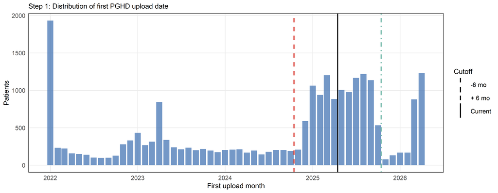

Distribution of first PGHD upload date by month. Vertical lines mark the three cutoff options. Patients to the right of a cutoff are excluded at Step 1.

### Step 2: Weekly Data Quality Threshold Sensitivity

Step 2 Sensitivity: Effect of varying the required minimum upload days per 7-day window.

| Quality criterion | Patients | Person-weeks | % patients retained | % weeks retained |
| --- | --- | --- | --- | --- |
| ≤0 missing (≥7 days present) | 13545 | 702142 | 98.3 | 57.2 |
| ≤1 missing (≥6 days present) | 13626 | 988784 | 98.9 | 80.5 |
| ≤2 missing (≥5 days present) | 13666 | 1055906 | 99.2 | 86.0 |
| ≤3 missing (≥4 days present) [current] | 13699 | 1092799 | 99.5 | 89.0 |
| ≤4 missing (≥3 days present) | 13730 | 1122275 | 99.7 | 91.4 |
| ≤5 missing (≥2 days present) | 13749 | 1149561 | 99.8 | 93.6 |
| ≤6 missing (≥1 days present) | 13773 | 1227624 | 100.0 | 100.0 |

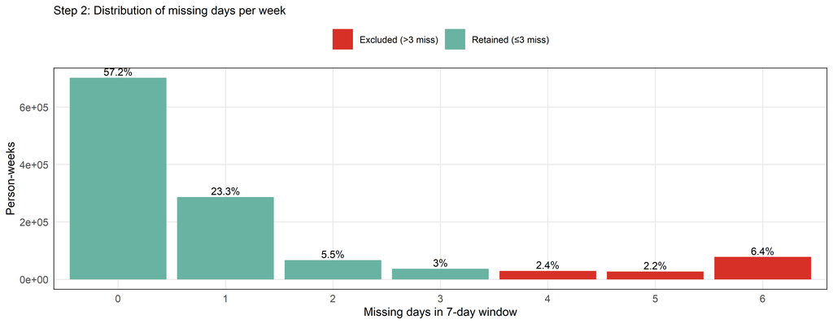

Distribution of missing days per 7-day window across all qualifying person-weeks (after Step 1). The current threshold (miss_days ≤ 3) retains the left portion of this distribution.

### Step 3: Minimum Baseline Length Sensitivity

Step 3 Sensitivity: Effect of varying the minimum required baseline length.

| Baseline length | Patients retained | Observation person-weeks | % of post-step2 patients |
| --- | --- | --- | --- |
| 2 weeks | 13265 | 1056777 | 99.4 |
| 4 weeks | 13213 | 1036391 | 99.0 |
| 6 weeks [current] | 13151 | 1016079 | 98.5 |
| 8 weeks | 13096 | 995786 | 98.1 |
| 10 weeks | 13049 | 975488 | 97.8 |
| 12 weeks | 12994 | 955286 | 97.4 |

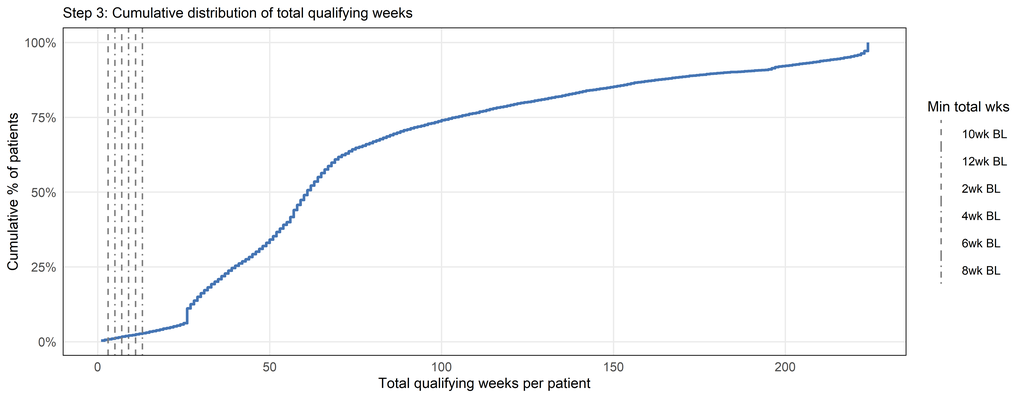

Cumulative distribution of total qualifying weeks per patient (after Steps 1–2). Patients to the left of each vertical line would be excluded by the corresponding minimum baseline requirement.

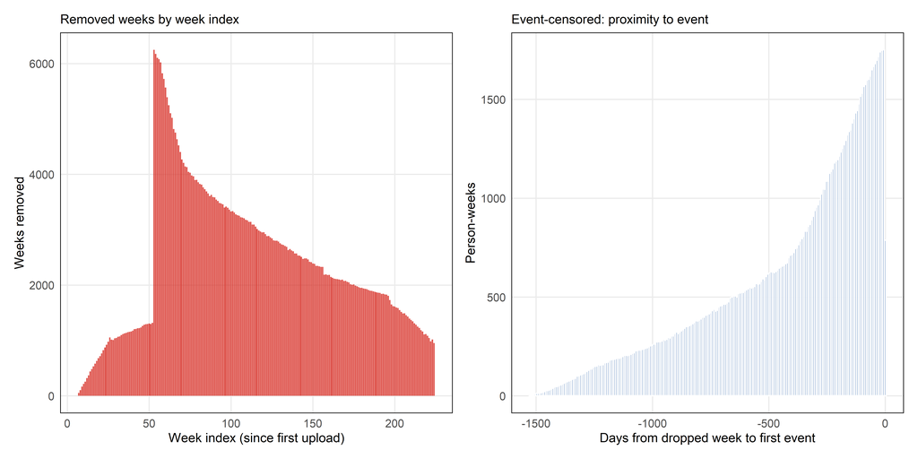

Left: Distribution of weekly_interval_index for removed person-weeks (weeks dropped by censoring). Right: Distribution of days_to_event at the time of removal for event-censored rows (i.e., how far in the future was the event relative to the dropped week?).

# Results: Study 1 — Pre-Event PGHD Surveillance Cohort

## Table 1. Sample Characteristics

| **Characteristic** | **Overall** N = 10,112<sup>1</sup> | **Death** N = 11<sup>1</sup> | **Inpatient** N = 747<sup>1</sup> | **ED Visit** N = 1,248<sup>1</sup> | **No Event** N = 8,106<sup>1</sup> | **p-value**<sup>2</sup> |
| --- | --- | --- | --- | --- | --- | --- |
| Baseline avg. steps (steps/day) | 5,255.5 (2,665.2); 5,040.6 (3,246.9, 7,004.0) | 3,321.8 (2,042.9); 2,202.4 (1,822.2, 5,147.0) | 4,645.4 (2,589.4); 4,402.4 (2,614.1, 6,307.3) | 5,039.9 (2,575.6); 4,760.3 (3,096.3, 6,638.3) | 5,347.5 (2,676.5); 5,125.4 (3,330.6, 7,119.9) | <0.001 |
| Baseline avg. missing days/week | 0.5 (0.6); 0.3 (0.2, 0.6) | 0.3 (0.2); 0.2 (0.2, 0.3) | 0.5 (0.5); 0.3 (0.2, 0.5) | 0.5 (0.6); 0.3 (0.2, 0.5) | 0.6 (0.6); 0.3 (0.2, 0.7) | 0.16 |
| Observation avg. steps (steps/day) | 5,374.9 (2,520.2); 5,219.0 (3,505.6, 7,024.6) | 3,932.1 (3,286.9); 2,570.5 (1,529.3, 5,784.8) | 4,716.4 (2,626.9); 4,516.9 (2,709.7, 6,344.8) | 5,148.4 (2,529.1); 4,915.7 (3,287.4, 6,794.3) | 5,472.3 (2,496.1); 5,322.2 (3,633.0, 7,103.2) | <0.001 |
| Observation avg. missing days/week | 0.6 (0.5); 0.3 (0.3, 0.6) | 0.6 (0.5); 0.5 (0.3, 0.7) | 0.5 (0.5); 0.3 (0.2, 0.5) | 0.5 (0.6); 0.3 (0.2, 0.6) | 0.6 (0.5); 0.4 (0.3, 0.6) | <0.001 |
| Total observation weeks (post-baseline) | 31.9 (14.7); 37.0 (20.0, 46.0) | 27.8 (10.0); 27.0 (21.0, 34.0) | 18.5 (12.1); 17.0 (9.0, 27.0) | 17.1 (11.7); 16.0 (7.0, 25.0) | 35.4 (13.1); 44.0 (24.0, 46.0) | <0.001 |
| Observation weeks with data coverage (%) | 91.7 (19.9); 100.0 (97.4, 100.0) | 96.8 (7.5); 100.0 (96.9, 100.0) | 94.9 (16.0); 100.0 (100.0, 100.0) | 94.2 (16.4); 100.0 (100.0, 100.0) | 91.0 (20.6); 100.0 (95.7, 100.0) | <0.001 |
| Age (years) | 52.2 (13.3); 52.0 (42.0, 62.0) | 63.1 (10.9); 68.0 (52.0, 73.0) | 54.2 (14.3); 54.0 (43.0, 65.0) | 52.8 (13.4); 53.0 (42.0, 63.0) | 51.9 (13.2); 51.0 (42.0, 61.0) | <0.001 |
| Unknown | 23 | 0 | 0 | 1 | 22 |  |
| Sex |  |  |  |  |  | <0.001 |
| Female | 1,915 (19%) | 0 (0%) | 166 (22%) | 280 (22%) | 1,469 (18%) |  |
| Male | 8,174 (81%) | 11 (100%) | 581 (78%) | 967 (78%) | 6,615 (82%) |  |
| Unknown | 23 | 0 | 0 | 1 | 22 |  |
| Race |  |  |  |  |  |  |
| American Indian or Alaska Native | 90 (1.0%) | 2 (25%) | 7 (1.0%) | 12 (1.0%) | 69 (0.9%) |  |
| Asian | 143 (1.5%) | 0 (0%) | 7 (1.0%) | 11 (0.9%) | 125 (1.7%) |  |
| Black or African American | 1,594 (17%) | 1 (13%) | 110 (16%) | 286 (24%) | 1,197 (16%) |  |
| Native Hawaiian or Other Pacific Islander | 86 (0.9%) | 0 (0%) | 6 (0.9%) | 6 (0.5%) | 74 (1.0%) |  |
| White | 7,320 (79%) | 5 (63%) | 561 (81%) | 860 (73%) | 5,894 (80%) |  |
| Unknown | 879 | 3 | 56 | 73 | 747 |  |
| Ethnicity |  |  |  |  |  | 0.059 |
| Hispanic or Latino | 987 (10%) | 1 (11%) | 65 (9.1%) | 150 (12%) | 771 (10%) |  |
| Not Hispanic or Latino | 8,649 (90%) | 8 (89%) | 651 (91%) | 1,069 (88%) | 6,921 (90%) |  |
| Unknown | 476 | 2 | 31 | 29 | 414 |  |
| Marital status |  |  |  |  |  |  |
| Divorced | 1,724 (17%) | 2 (20%) | 154 (21%) | 246 (20%) | 1,322 (17%) |  |
| Married | 6,052 (61%) | 7 (70%) | 418 (57%) | 683 (55%) | 4,944 (62%) |  |
| Never Married | 1,765 (18%) | 1 (10%) | 119 (16%) | 236 (19%) | 1,409 (18%) |  |
| Separated | 275 (2.8%) | 0 (0%) | 29 (3.9%) | 54 (4.4%) | 192 (2.4%) |  |
| Widowed | 108 (1.1%) | 0 (0%) | 17 (2.3%) | 16 (1.3%) | 75 (0.9%) |  |
| Unknown | 188 | 1 | 10 | 13 | 164 |  |

[output cut: 104 more lines]

<sup>1</sup> Mean (SD); Median (Q1, Q3); n (%)  
<sup>2</sup> Kruskal-Wallis rank sum test; Fisher’s exact test; NA

## Figure 2. Time to First Composite Event

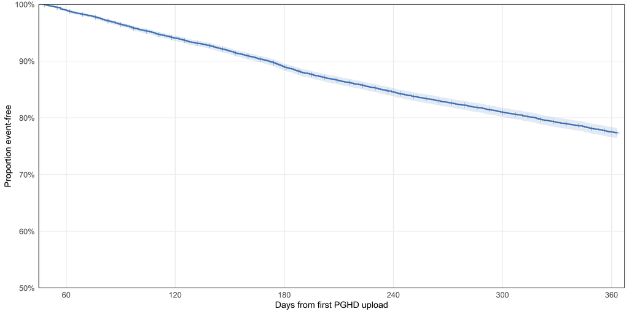

Figure 2. Kaplan-Meier survival curve for time from first PGHD upload to first composite event (ED visit, inpatient admission, or death) among the analytic cohort. The y-axis shows the proportion of patients remaining event-free. Tick marks indicate censored observations. Shaded band represents the 95% pointwise confidence interval.

## Figure 3. Step Trajectories Before First Event

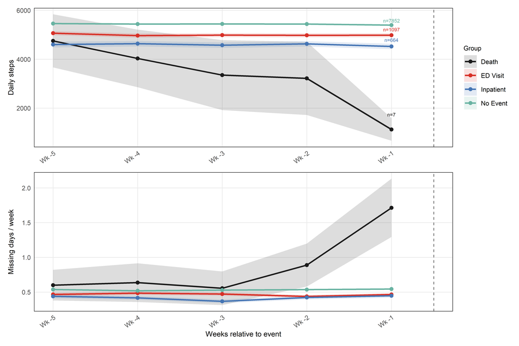

## Table 2. Predictive Model Performance

Table 2. Model performance on the 30% patient-level hold-out test set.

| Feature set | 14-day horizon AUC | 14-day horizon PR-AUC | 14-day horizon Cal. slope | 14-day horizon Events | 30-day horizon AUC | 30-day horizon PR-AUC | 30-day horizon Cal. slope | 30-day horizon Test N | 30-day horizon Events |
| --- | --- | --- | --- | --- | --- | --- | --- | --- | --- |
| Null model (event rate) | 0.5000 | 0.0111 | — | 1,074 | 0.5000 | 0.0229 | — | 96,706 | 2,219 |
| **Logistic regression** |  |  |  |  |  |  |  |  |  |
| Static only | 0.7569 | 0.0358 | 1.1158 | 1,074 | 0.7551 | 0.0725 | 1.2449 | 96,706 | 2,219 |
| Steps + static | 0.7516 | 0.0352 | 1.0596 | 1,074 | 0.7505 | 0.0712 | 1.1897 | 96,706 | 2,219 |
| Steps only | 0.5391 | 0.0126 | 0.3760 | 1,074 | 0.5421 | 0.0261 | 0.4755 | 96,706 | 2,219 |
| **XGBoost** |  |  |  |  |  |  |  |  |  |
| Static only | 0.7538 | 0.0371 | 1.2355 | 1,074 | 0.7517 | 0.0748 | 1.2713 | 96,706 | 2,219 |
| Steps + static | 0.7475 | 0.0338 | 2.1844 | 1,074 | 0.7457 | 0.0706 | 5.7053 | 96,706 | 2,219 |
| Steps only | 0.5393 | 0.0125 | 1.5968 | 1,074 | 0.5428 | 0.0259 | 0.7746 | 96,706 | 2,219 |

### Sensitivity Analyses

Table S1. Sensitivity Analysis A: Effect of relaxing the weekly data-quality filter (miss_days ≤ 3 → ≤ 6) on 30-day AUC. ΔAUC = AUC(relaxed) − AUC(primary); positive values indicate improvement under the relaxed filter.

| Feature set | AUC (primary, miss/wk ≤3) | AUC (relaxed, miss/wk ≤6) | ΔAUC |
| --- | --- | --- | --- |
| **Logistic regression** |  |  |  |
| Static only | 0.7551 | 0.7570 | 0.0019 |
| Steps + static | 0.7505 | 0.7547 | 0.0042 |
| Steps only | 0.5421 | 0.5515 | 0.0094 |
| **XGBoost** |  |  |  |
| Static only | 0.7517 | 0.7499 | -0.0018 |
| Steps + static | 0.7457 | 0.7542 | 0.0085 |
| Steps only | 0.5428 | 0.5514 | 0.0086 |

## Figure 4. ROC Curves at 30-Day Horizon

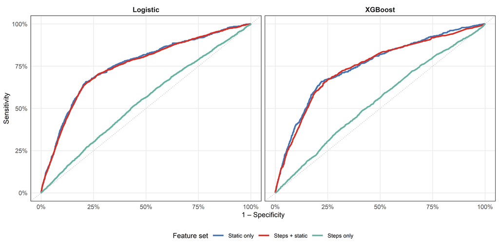

## Figure 5. XGBoost Feature Importance: Steps + Static Model

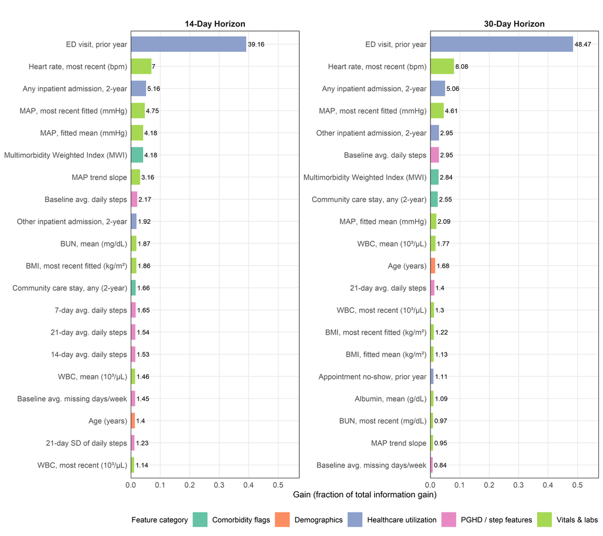

Figure 5. Top 20 XGBoost feature importances (Gain): Steps + Static, 14-Day and 30-Day Horizons. Bars filled by feature category (colorblind-friendly Set2 palette). Gain = fractional contribution to total information gain across all trees. Labels show Gain x 100.

## Figure 6. Logistic Regression Coefficients: Steps + Static Model

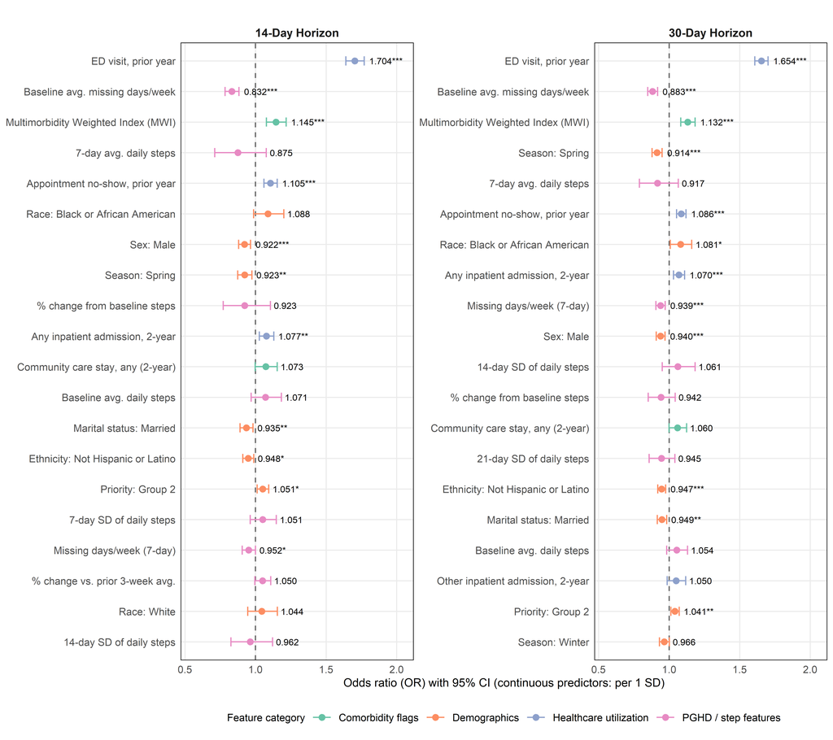

Figure 6. Top 20 logistic regression features by absolute log-odds: Steps + Static, 14-Day and 30-Day Horizons. Forest plot shows odds ratios (OR) with 95% Wald confidence intervals. Vertical line at OR = 1 (null). Colored by feature category (Set2 palette). Significance on labels: *** p<0.001, ** p<0.01, * p<0.05. ORs from 3:1 patient-aware undersampled data with case weights; magnitudes reflect association direction and relative strength within the model.

*Analysis completed: 2026-05-22 11:56*  
*Seed: 2026 | R version: R version 4.5.0 (2025-04-11 ucrt)*